# [기본 작업]

## 1) 라이브러리/모듈 import

```python
import pandas as pd
import numpy as np

import matplotlib.pyplot as plt
import seaborn as sns

import warnings
warnings.filterwarnings('ignore')
```

## 2) data file 읽어서 datetime변환 - train, test

```python
train=pd.read_csv('./data/train.csv',parse_dates=['datetime'])
test = pd.read_csv('./data/test.csv',parse_dates=['datetime'])
```

```python
train["year"] = train["datetime"].dt.year
train["month"] = train["datetime"].dt.month
train["day"] = train["datetime"].dt.day
train["hour"] = train["datetime"].dt.hour
train["dayofweek"] = train["datetime"].dt.dayofweek
#분과 초는 생성하지 않음
train.head()
```

```python
test["year"] = test["datetime"].dt.year
test["month"] = test["datetime"].dt.month
test["day"] = test["datetime"].dt.day
test["hour"] = test["datetime"].dt.hour
test["dayofweek"] = test["datetime"].dt.dayofweek
#분과 초는 생성하지 않음
test.head()
```

## 3) 불필요한 feature 삭제

```python
train.drop(['datetime','atemp', 'casual', 'registered'], axis=1, inplace=True)
```

```python
train.head()
```

```python
test.drop(['datetime','atemp'], axis=1, inplace=True)
```

```python
test.head()
```

## 4) Feature Selection

- **drop한 feature를 제외하고 선택**
- **day의 경우 큰 의미가 없으므로 제외**
- **holiday는 workingday와 상보적 관계이므로 제외**

```python
feature_names = ["year", "month", "hour",
                 "weather", "temp", "humidity", "windspeed",
                 "season", "workingday", "dayofweek"]
```

## 5) xtrain, ytrain 과 xtest 설정

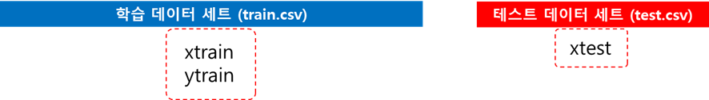

```python
xtrain = train[feature_names]
```

```python
ytrain = train["count"]
```

```python
xtest = test[feature_names]
```

## 6) 성능평가방법 확인

### 6.1) RMSLE(Root Mean Square Log Error)

- RMSE(Root Mean Squared Error) 에 L(Log)가 추가됨
- 즉, 로그값을 취하여 오차를 구하는 RMSE 방식
- Error이므로 값이 작을 수록(0에 가까운 값이 나올 수록) 오류가 적다는 의미

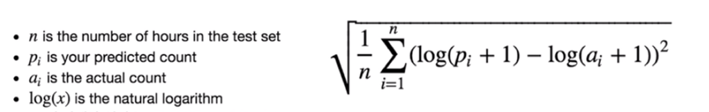

### [참고]RMSE (Root Mean Squared Error)

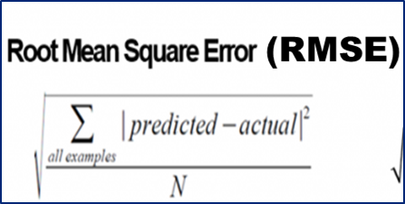

### [참고] log(X) 보다 log1p(X) 를 선호하는 이유

- **log0= -무한대, log1=0 이므로 x>=0 일 경우 log1p(x)>=0이 보장됨**
- **(X값이 0이상의 범위라면) -무한대를 피하여 계산오류를 방지할 수 있어 일반적으로 log1p()를 선호함**

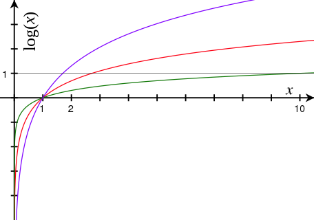

### 6.2) RMSLE 함수 작성

- **사이킷런은 RMSLE를 제공하지 않아 직접 만들어서 사용해야 함**

```python
from sklearn.metrics import mean_squared_error, mean_absolute_error
```

- **log1p(x) : log(X+1)**

```python
np.log1p(0)  #log(1)
```

```python
np.log1p(1)  #log(2)
```

```python
np.sqrt(4)
```

```python
np.sqrt(25)
```

```python
def rmsle(pred, y):
    log_pred = np.log1p(pred)
    log_y = np.log1p(y)
    squared_error = (log_pred-log_y)**2
    rmsle = np.sqrt(np.mean(squared_error))
    return rmsle
```

### 6.3) 추가로 RMSE, MAE도 작성

```python
def rmse(pred, y):
    return np.sqrt(mean_squared_error(pred, y))
```

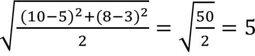

```python
rmse([10, 8], [5,3])
```

```python
rmsle(10, 8)
```

```python
def mae(pred, y):
    return mean_absolute_error(pred, y)
```

```python
mae([5, 8], [10,3])
```

### 6.4) evaluate_regr() - RMSLE, RMSE, MAE를 모두 계산하는 함수

```python
def evaluate_regr(pred, y):
    rmsle_val = rmsle(pred, y)
    rmse_val  = rmse(pred, y)
    mae_val  = mae(pred, y)

    print('RMSLE: {0: .3f}, RMSE: {1: .3f}, MAE: {2: .3f}'.format(rmsle_val, rmse_val, mae_val))
```

# [성능 향상을 위한 과정]

# Step 1. 대부분의 feature로 일단 시작

- **상기의 feature selection으로 시작**
- **아웃라이어 제거, 인코딩, log변환 등 모두 안한 상태**
- **학습/예측모델은 회귀모델 (LinearRegression)**

## 1.1)모듈 import

```python
from sklearn.model_selection import train_test_split
```

```python
from sklearn.linear_model import LinearRegression
```

## 1.2) validation을 위한 train 데이터셋 분리

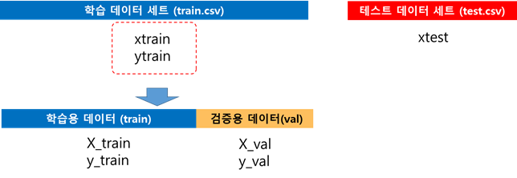

```python
X_train, X_val, y_train, y_val =train_test_split(xtrain, ytrain, test_size=0.3, random_state=0)
```

## 1.2) 모델설정~평가

```python
linear_reg = LinearRegression()   #모델 설정
```

```python
linear_reg.fit(X_train, y_train)   #학습
```

```python
prediction = linear_reg.predict(X_val)  #예측
```

```python
evaluate_regr(prediction, y_val) #평가
```

# Step 2. train set에서 아웃라이어 제거 - Target (count) 기준

- **train set : train.csv에서 로드한 데이터**
- **단 test.csv에서 로드한 데이터 (xtest)는 target이 없으므로 변경없음**

## 2.1) 아웃라이어 제거

```python
train.shape
```

```python
train['count'].mean()
```

```python
train["count"].std()
```

```python
train['count'].mean()-train["count"].std()*3
```

```python
train['count'].mean()+train["count"].std()*3
```

```python
abs(train['count']-train['count'].mean()) <= (train["count"].std()*3)
```

```python
train[abs(train['count']-train['count'].mean()) <= (train["count"].std()*3)]
```

```python
trainWithoutOutliers=train[abs(train['count']-train['count'].mean()) <= (train["count"].std()*3)]
```

```python
trainWithoutOutliers.shape
```

## 2.2) 아웃라이어 제거 후 xtrain, ytrain 재설정

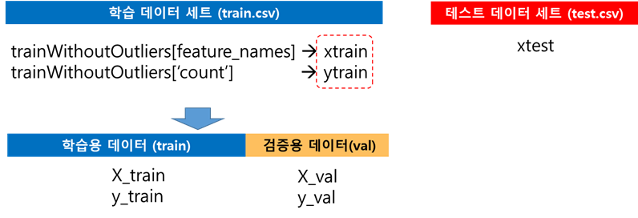

```python
xtrain = trainWithoutOutliers[feature_names]
# xtrain = trainWithoutOutliers[["year", "month", "hour", ..., "dayofweek"]] 와 동일한 표현
```

```python
ytrain = trainWithoutOutliers["count"]
```

## 2.3) 아웃라이어 제거xtrain, ytrain 재설정 되었으므로 다시 data split

```python
X_train, X_val, y_train, y_val =train_test_split(xtrain, ytrain, test_size=0.3, random_state=0)
```

## 2.4) 모델설정~평가

```python
linear_reg = LinearRegression()    #모델 설정
linear_reg.fit(X_train, y_train)   #학습
```

```python
prediction = linear_reg.predict(X_val)  #검증
evaluate_regr(prediction, y_val)  #평가
```

## 2.5) TopErrorData()함수 - 실제값과 예측값 차이가 가장 큰 데이터 5개 출력

```python
result_df = pd.DataFrame(y_val.values, columns=['real_count'])
```

```python
result_df['predicted_count']= np.round(prediction)
```

```python
result_df['diff'] = result_df['real_count'] - result_df['predicted_count']
```

```python
result_df['diff']
```

```python
result_df['diff'] = abs(result_df['real_count'] - result_df['predicted_count'])
```

```python
result_df['diff']
```

```python
result_df.sort_values('diff', ascending=False)
```

# Step3. Target값 로그 변환!

## 3.1) log1p() 함수로 로그변환

```python
ytrain_log = np.log1p(ytrain)
```

## 3.2) 로그 변환된 y_train_log를 반영하여 학습/테스트 데이터 셋 분할

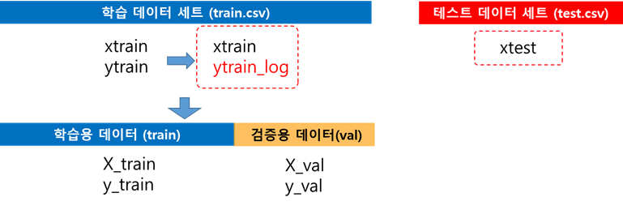

```python
X_train, X_val, y_train, y_val = train_test_split(xtrain, ytrain_log, test_size=0.3, random_state=0)
```

## 3.3) 모델설정~예측

```python
linear_reg = LinearRegression()
```

```python
linear_reg.fit(X_train, y_train)
```

```python
prediction = linear_reg.predict(X_val)
```

## 3.4) [알아두기] log1p() VS expm1()

- **log1p: log (1 plus X)**
- **expm1: exp (X) minus 1**

```python
k1=105
k2=np.log1p(k1)
k3=np.expm1(k2)
print(k1,np.round(k2,2),np.round(k3,2))
```

## 3.5) expm1 처리 후 성능평가

- **테스트 데이터 셋의 Target 값은 Log 변환되었으므로**
- **예측값(prediction), 실제값(ytest) 둘다 expm1 처리, 원래 scale로 변환 후 성능평가 진행**

```python
yval_exp = np.expm1(y_val)
```

```python
prediction_exp = np.expm1(prediction)
```

```python
evaluate_regr(prediction_exp, yval_exp)
```

### 각 변수의 회귀계수값을 시각화 해 보자!

```python
coef = pd.Series(data=linear_reg.coef_, index=linear_reg.feature_names_in_)
```

```python
coef
```

- (참고) linearRegression 클래스
- https://scikit-learn.org/stable/modules/generated/sklearn.linear_model.LinearRegression.html?highlight=linearregression#sklearn.linear_model.LinearRegression

```python
coef_sort = coef.sort_values(ascending=False)
```

```python
coef_sort
```

```python
sns.barplot(x=coef_sort.values, y=coef_sort.index)
plt.show()
```

[output not shown]

# Step4. Category형 feature 원-핫 인코딩

## 4.1) 원-핫 인코딩 수행 - train 셋, test 셋 모두

```python
xtrain_ohe = pd.get_dummies(xtrain, columns=['year', 'month', 'hour', 'dayofweek', 'workingday','season','weather'])
```

```python
xtrain_ohe
```

```python
xtest_ohe = pd.get_dummies(xtest, columns=['year', 'month', 'hour', 'dayofweek', 'workingday','season','weather'])
```

```python
xtest_ohe
```

- https://pandas.pydata.org/docs/reference/api/pandas.get_dummies.html
- If columns is None then all the columns with object or category dtype will be converted.

## 4.2) 원-핫 인코딩이 적용된 데이터 세트 기반으로 학습/예측 데이터 분할

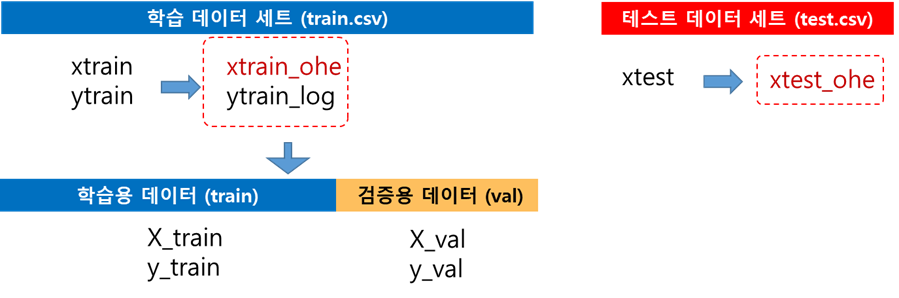

```python
X_train, X_val, y_train, y_val = train_test_split(xtrain_ohe, ytrain_log, test_size=0.3, random_state=0)
```

### 4.3) 모델설정~예측

```python
lr_reg = LinearRegression()
```

```python
linear_reg.fit(X_train, y_train)
```

```python
prediction = linear_reg.predict(X_val)
```

## 4.5) expm1 처리 후 성능평가

- **테스트 데이터 셋의 Target 값은 Log 변환되었으므로**
- **예측값(prediction), 실제값(ytest) 둘다 expm1 처리, 원래 scale로 변환 후 성능평가 진행**

```python
yval_exp = np.expm1(y_val)
```

```python
prediction_exp = np.expm1(prediction)
```

```python
evaluate_regr(prediction_exp, yval_exp)
```

### 그럼 이제 다양한 회귀모델을 적용해 보자-Ridge, Lasso추가!

# Step5. 회귀 모델 다양화

## 5.1) 모듈 import

```python
from sklearn.linear_model import Ridge, Lasso
```

## 5.2) 모델 설정

- **LinearRegression**
- **Ridge**
- **Lasso**

```python
lr_reg = LinearRegression()
```

```python
ridge_reg = Ridge(alpha=10)
```

```python
lasso_reg = Lasso(alpha=0.01)
```

## 5.3) get_model_predict()

- 3가지 회귀 모델과 학습/테스트 데이터 셋을 입력하면 학습/예측 후 성능 평가 수치를 동시에 보여주는 함수
- **만약 is_expm1=True 이면 y_test와 pred를 모두 expm1처리하여 원래 scale로 복귀시켜서 evaluate함**

```python
# (참고) 오브젝트(estimator).__class__.__name__ --> class이름을 알려줌
lr_reg.__class__.__name__
```

```python
ridge_reg.__class__.__name__
```

```python
lasso_reg.__class__.__name__
```

```python
def get_model_predict(model, X_train, X_test, y_train, y_test, is_expm1=False):
    model.fit(X_train, y_train)
    pred = model.predict(X_test)
    if is_expm1 :
        y_test = np.expm1(y_test)
        pred = np.expm1(pred)
    print('###', model.__class__.__name__, '###')
    evaluate_regr(pred, y_test)
```

## 5.4) 다양한 회귀 모델의 성능 비교 - Ridge, Lasso 추가

```python
for model in[lr_reg , ridge_reg, lasso_reg]:
    get_model_predict(model, X_train, X_val, y_train, y_val,is_expm1=True)
```

# Step7. 규제회귀의 하이퍼 파라미터 최적화

## 6.1) 모듈 import

```python
from sklearn.model_selection import GridSearchCV
from sklearn.metrics import make_scorer
```

## 6.2) print_best_params() - 규제회귀모델별 최적의 alpha값 찾아서 출력

```python
def print_best_params(model, params):
    grid_model = GridSearchCV(model, param_grid=params, scoring='neg_mean_squared_error', cv=5)

    grid_model.fit(xtrain_ohe, ytrain_log)

    rmse = np.sqrt(-1* grid_model.best_score_)    # ex) -300,-200,-100중에 -100이 best score로 선택 --> MSE를 100으로 수정

    print('{0} 5 CV 시 최적 평균 RMSE 값: {1}, 최적 alpha:{2}'.format(model.__class__.__name__,
                                        np.round(rmse, 4), grid_model.best_params_))
```

```python
ridge_params = { 'alpha':[0.05, 0.1, 1, 5, 8, 10, 12, 15, 20] }
lasso_params = { 'alpha':[0.001, 0.005, 0.008, 0.05, 0.03, 0.1, 0.5, 1,5, 10] }
```

```python
print_best_params(ridge_reg, ridge_params)
```

```python
 print_best_params(lasso_reg, lasso_params)
```

## 6.3) 최적의 alpha값으로 Ridge, Lasso모델 재설정

```python
ridge_reg = Ridge(alpha=5)
```

```python
lasso_reg = Lasso(alpha=0.001)
```

## 6.4) 하이퍼 파라미터 최적화 이후의 성능 비교

```python
for model in[lr_reg, ridge_reg, lasso_reg]:
    get_model_predict(model, X_train, X_val, y_train, y_val,is_expm1=True)
```

## 6.7) 회귀 계수가 높은 feature 시각화 - Linear Regression 모델 기준

```python
lr_reg.coef_
```

```python
xtrain_ohe.columns
```

```python
lr_reg.feature_names_in_
```

```python
coef=pd.Series(data=lr_reg.coef_, index=xtrain_ohe.columns)
```

```python
coef
```

```python
coef_sort=coef.sort_values(ascending=False)[:10]
```

```python
coef_sort  # series 타입
```

```python
sns.barplot(x=coef_sort.values, y=coef_sort.index)
plt.show()
```

[output not shown]

### 이번에는 RandomforrestRegressor를 이용하여 앙상블 학습을 해 보자!

# Step6. 앙상블 적용-RandomforestRegressor

```python
from sklearn.ensemble import RandomForestRegressor
```

## 6.2) 모델 설정

- https://scikit-learn.org/stable/modules/generated/sklearn.ensemble.RandomForestRegressor.html?highlight=randomforestregressor#sklearn.ensemble.RandomForestRegressor

```python
rf_reg = RandomForestRegressor(n_estimators=500)
```

## 6.3) 학습/예측/성능평가

```python
get_model_predict(rf_reg,X_train, X_val, y_train, y_val,is_expm1=True)
```

- n_estimators=100 으로 해 보면?
- n_estimators=1000 으로 해 보면?

# [Prediction]

### test.cvs 데이터셋, RandomForrestRegression으로 예측

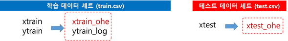

### 1) 최종 선택된 rf_reg모델 사용, test 데이터 세트로 predict

```python
pred = rf_reg.predict(xtest_ohe)
```

### 2) 예측값 expm1()처리 - 예측값이 로그변환된 값이므로 스케일링 복구

```python
pred = np.expm1(pred)
```

```python
pred[0:10]
```

### 3) train set의 y값(ytrain)과 예측한 데이터(pred) 시각화

```python
fig,(ax1,ax2)= plt.subplots(ncols=2, figsize=(12, 5))

sns.histplot(ytrain,ax=ax1,bins=50)
ax1.set_title("train")
sns.histplot(pred,ax=ax2,bins=50)
ax2.set_title("test")

plt.show()
```

[output not shown]

# [SUBMISSION]

```python
submission=pd.read_csv("./data/sampleSubmission.csv")
submission
```

```python
submission["count"] = pred
```

```python
submission.head()
```

```python
submission.to_csv("./data/mySubmission.csv", index=False)   # 각 행의 index는 기록하지 않는다는 뜻
```

### 최종 제출해서 score를 확인해 보자!